# 波士顿房价预测二

1.首先进行数据清洗以及特征提取 下面将处理离群点、缺失值、偏态分布以及特征提取。使用的工具是 Pandas 数据分析工具、Seaborn 统计分析可视化工具。 涉及知识点： 缺失值处理 box-cox transformation 法处理偏态分布数据 特征提取

2.2 数据清洗

1. 分析数据 train.csv - 训练集 test.csv- 测试集 Document - 特征描述文本（需要较详细的阅读） 以下做一个简单的归类： 类别 特征 房价 SalePrice 地理位置 LotFrontage，Street，Alley，LotShape，LotConfig，LandSlope，LandContour，Neighborhood，Condition1，Condition2， 总体 MSSubClass，MSZoning，BldgType，HouseStyle，OverallQual，OverallCond 局部 RoofStyle，RoofMatl，Exterior1st，Exterior2nd， MasVnrType，MasVnrArea，ExterQual，ExterCond，Foundation 卧室厨卫浴 FullBath，HalfBath，Bedroom，Kitchen，KitchenQual，TotRmsAbvGrd，Functional，Fireplaces，FireplaceQu 地下室 BsmtQual，BsmtCond，BsmtExposure，BsmtFinType1， BsmtFinType2，BsmtFullBath，BsmtHalfBath 车库 GarageType，GarageYrBlt，GarageFinish，GarageCars，GarageArea，GarageQual，GarageCond 水电气暖 Utilities，Heating，HeatingQC，CentralAir，Electrical 其它 PoolQC，Fence， MiscFeature，MiscVal 面积 LotArea，1stFlrSF，2ndFlrSF，LowQualFinSF，GrLivArea，BsmtFinSF1，BsmtFinSF2，BsmtUnfSF，TotalBsmtSF，WoodDeckSF，OpenPorchSF，PoolArea，3SsnPorch，EnclosedPorch，ScreenPorch 时间 MoSold，YrSold，YearBuilt，YearRemodAdd 出售 SaleType，SaleCondition
1. 以 DataFrame 形式载入数据

```python
import warnings  # 忽略无意义的警告

def ignore_warn(*arfs, **kwargs):
    pass

warnings.warn = ignore_warn
```

```python
import pandas as pd
import numpy as np
import seaborn as sns
import matplotlib.pyplot as plt
%matplotlib inline
train=pd.read_csv('train.csv')# 读取训练集数据
test=pd.read_csv('test.csv') # 读取测试集数据
train.drop(['Id'],axis=1,inplace=True)
test.drop(['Id'],axis=1,inplace=True)
```

1. 离群点

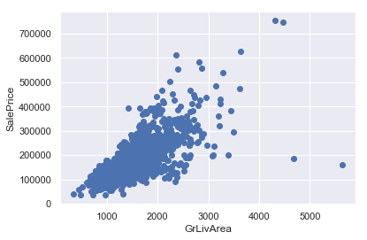

```python
sns.set(style='darkgrid')  # 设置图片背景
fig = plt.figure()  # 使用plt作图工具
ax = plt.scatter(train['GrLivArea'], train['SalePrice'])  # 使用散点图观察房价与居住面积的关系
plt.xlabel('GrLivArea')  # 设置横坐标
plt.ylabel('SalePrice')  # 设置纵坐标
plt.show()  # 图片显示
```

```python
# 删除居住面积大于4000的数据
train = train.drop(train[train['GrLivArea'] > 4000].index)
```

4.SalePrice - 目标属性 房价是连续的属性，使用 Seaborn 绘图观察数据分布。

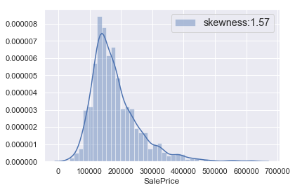

```python
g = sns.distplot(train['SalePrice'], kde=True, label='skewness:%.2f' %
                 train['SalePrice'].skew())  # 绘制柱状图，kde=True表示绘制拟合曲线，skew()函数计算房价的偏态系数
plt.legend(loc='best', fontsize='large')  # 设置 legend 的位置和大小
g.set(xlabel='SalePrice')  # 设置横坐标
plt.show()
```

房价属于右偏态分布，使用 Log Transformation 方法。

```python
train['SalePrice'] = np.log(train['SalePrice'])  # 对房价取对数
train['SalePrice'].skew()  # 检查新数据偏态系数
```

```
0.06544882031646646
```

这时候，偏态系数从 1.57 降为 0.065。

1. 关联系数

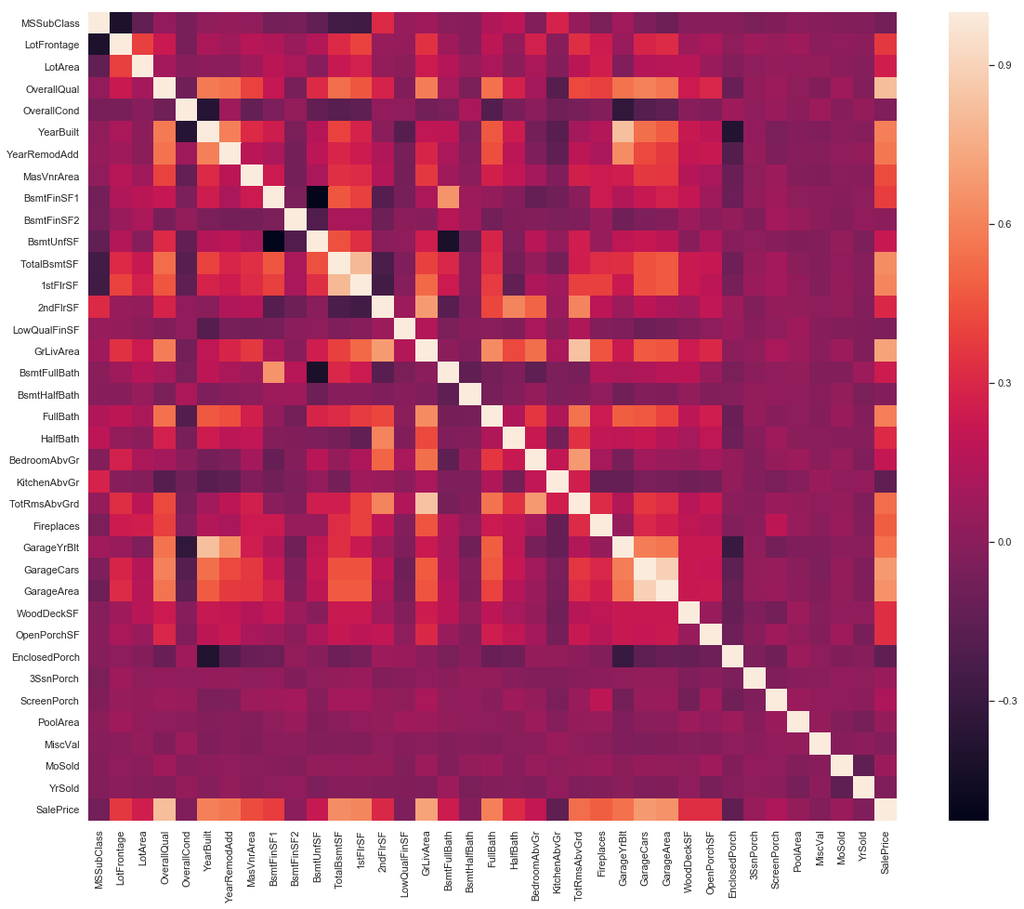

```python
plt.subplots(figsize=(20, 16))  # 设置图形大小
sns.heatmap(train.corr(), square=True)  # corr()函数计算关联系数，并绘图
plt.show()
```

1. 合并训练集和测试集

```python
data = pd.concat([train, test], axis=0, ignore_index=True)
# 合并测试集和训练集，命名为data
```

1. 缺失值

```python
def null_count(data):  # 定义 null 值查找函数，函数名 null_count
    null_data = data.isnull().sum()  # 查找各个特征 null 值并计算数量
    null_data = null_data.drop(null_data[null_data == 0].index).sort_values(
        ascending=False)  # 删除数目为零的特征，降序排列
    return null_data  # 返回结果

null_count(data)  # 调用 null_count 函数统计 data 的 null，输出结果
```

```
PoolQC          2907
MiscFeature     2810
Alley           2717
Fence           2345
SalePrice       1459
FireplaceQu     1420
LotFrontage      486
GarageQual       159
GarageCond       159
GarageFinish     159
GarageYrBlt      159
GarageType       157
BsmtExposure      82
BsmtCond          82
BsmtQual          81
BsmtFinType2      80
BsmtFinType1      79
MasVnrType        24
MasVnrArea        23
MSZoning           4
BsmtFullBath       2
BsmtHalfBath       2
Utilities          2
Functional         2
Electrical         1
BsmtUnfSF          1
Exterior1st        1
Exterior2nd        1
TotalBsmtSF        1
GarageCars         1
BsmtFinSF2         1
BsmtFinSF1         1
KitchenQual        1
SaleType           1
GarageArea         1
dtype: int64
```

有些特征数据的 null 值代表对应样例没有这个属性（以下称之为原因一）。例如特征 BsmtCond，大量 null 值正是由于房屋没有地下室。所以，我们利用与之相关的 TotalBsmtSF 进行判断：TotalBsmtSF = 0 则没有地下室，TotalBsmtSF > 0 则是其它原因导致的数据不完整（以下称之为原因二），0 为判断阈值。写段代码进行判断：

```python
a = 0
# 查找所有 BsmtCond 缺失的样例所对应 TotalBsmtSF 值
null_set = data[data['BsmtCond'].isnull()]['TotalBsmtSF']
for i in null_set:  # 统计其中 TotalBsmtSF 大于0的样例的数目
    if i != 0:
        a += 1
print(a)  # a 如果还等于零，说明 BsmtCond 的 null 值全部是原因一造成的
```

```
4
```

具有这种属性的特征包括： Alley，BsmtQual，BsmtCond，BsmtExposure，BsmtFinType1，BsmtFinType2，FireplaceQu，GarageType，GarageFinish，GarageQual，GarageCond，PoolQC，Fence 我们认为 Alley，FireplaceQu，Fence null 值来自于原因一。

```python
No_inplace = ['Alley', 'FireplaceQu', 'Fence']
for feature in No_inplace:
    data[feature].fillna('U', inplace=True)  # 使用 ‘U’ null 值
```

地下室相关的特征缺失两种原因都有。原因一导致的 null 用 ‘U’ 或 ‘0’ 填充。原因二导致的使用众数填充。

```python
# 定义函数sp_null_index，用来查找由原因二导致缺失的数据的 index，以列表形式返回。输入变量为：数据集 data，特征 feature，用来判断的特征 judge_feature, 判断阈值 judge_value
def sp_null_index(data, feature, judge_feature, judge_value):
    # 查找缺失值的 index，列表名 null_index
    null_index = data[data[feature].isnull()].index
    sp_index = [i for i in null_index if data[judge_feature][i] !=
                judge_value]  # Python 列表推导式。查找 null_index 中属于原因二的 index
    return sp_index  # 返回结果

# 定义 fill_null 函数，分类填充 null 值。输入变量：特征列表 features 缺失值分类填充，replace_value 为原因一填充值，其它与上同
def fill_null(data, features, judge_feature, judge_value, replace_value):
    for feature in features:
        # 调用 sp_null_index 获取原因二导致的 index 集合，命名为 sp_index
        sp_index = sp_null_index(data, feature, judge_feature, judge_value)
        # 所有 null 值使用 replace_value 填充
        data[feature].fillna(replace_value, inplace=True)
        for i in sp_index:  # sp_index 中 index 的数据使用众数替换
            data[feature].iloc[i] = data[feature].mode()[0]
    return data  # 返回填充好的数据集 data

zero_replace = ['BsmtHalfBath', 'BsmtHalfBath',
                'BsmtFullBath', 'BsmtUnfSF', 'TotalBsmtSF','BsmtFinSF2','BsmtFinSF1']  # 这些属性将使用0填充
for feature in zero_replace:
    data[feature].fillna(0.0, inplace=True)

features = ['BsmtQual', 'BsmtCond', 'BsmtExposure',
            'BsmtFinType1', 'BsmtFinType2']
# 调用 fill_null 函数分类填充
data = fill_null(data, features, 'TotalBsmtSF', 0.0, 'U')
```

PoolQC 调用 fill_null 函数填充。

```python
data = fill_null(data, ['PoolQC'], 'PoolArea', 0, 'U')
```

Exterior1st，Electrical，Exterior2nd，KitchenQual，SaleType 众数填充

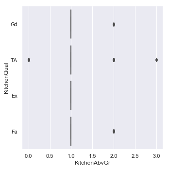

```python
g = sns.factorplot(x='KitchenAbvGr', y='KitchenQual', data=data,
                   kind='box')  # 绘制箱型图观察 KitchenQual 与其他属性的关系
# itchenAbvGr 特征值为1，根据下图，null 使用众数补全。
data[data['KitchenQual'].isnull()]['KitchenAbvGr']
plt.show()
```

```python
mode_inplace = ['MSZoning', 'Utilities', 'Exterior1st', 'Electrical',
                'Exterior2nd', 'KitchenQual', 'SaleType']  # 这些属性使用众数补全
for feature in mode_inplace:
    data[feature].fillna(data[feature].mode()[0], inplace=True)
```

```python
data['Functional'].fillna('Typ',inplace=True)
```

```python
# MasVnrType 和 MasVnrArea 都缺失的可以看做没有 Masory
data[data['MasVnrType'].isnull()]['MasVnrArea']
```

```
234       NaN
528       NaN
649       NaN
934       NaN
971       NaN
975       NaN
1240      NaN
1275      NaN
1687      NaN
1702      NaN
1878      NaN
1988      NaN
2000      NaN
2037      NaN
2307      NaN
2321      NaN
2336      NaN
2345      NaN
2364      NaN
2588      NaN
2606    198.0
2653      NaN
2682      NaN
2858      NaN
Name: MasVnrArea, dtype: float64
```

Masonry 相关特征

```python
data['MasVnrArea'].fillna(0.0, inplace=True)
data = fill_null(data, ['MasVnrType'], 'MasVnrArea', 0.0, 'U')
```

Garagy 相关的特征

```python
for feature in ['GarageCars', 'GarageArea']:
    # GarageCars，GarageArea null 值由原因二产生，使用众数替代
    data[feature].fillna(data[feature].mode()[0], inplace=True)
# GarageType 缺失值看做没有 Garage, 使用 ‘U’ 替代。
data['GarageType'].fillna('U', inplace=True)
features = ['GarageFinish', 'GarageQual', 'GarageCond']
data = fill_null(data, features, 'GarageType', 'U', 'U')  # 没有 Garage 使用‘U’替代，否则使用众数替代。
# 没有 Garage 的 GarageYrBlt 使用0替代，否则使用众数替代。
data = fill_null(data, ['GarageYrBlt'], 'GarageType', 'U', 0)
```

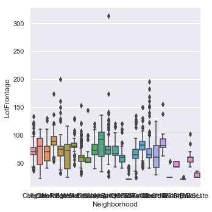

```python
# 绘图观察 Neighborhood 与 LotFrontage 关系
g = sns.factorplot(x='Neighborhood', y='LotFrontage', data=data, kind='box')
data["LotFrontage"] = data.groupby("Neighborhood")["LotFrontage"].transform(
    lambda i: i.fillna(i.median()))  # 分组并使用均值替换 null 值
plt.show()
```

MiscFeature null 值看做没有这类特征，使用‘U’填充。

```python
data['MiscFeature'].fillna('U',inplace=True)
```

1. 特征提取 隐藏特征

```python
data['TotalSF'] = data['TotalBsmtSF'] + data['1stFlrSF'] + \
    data['2ndFlrSF']  # 增加特征 TotalSF （地下室、一层、二层面积之和））
```

序列提取 / 归一化 使用 sklearn LabelEncoder 进行数字化以及归一化，用数字来表示某些属性的优劣程度。

```python
from sklearn.preprocessing import LabelEncoder
features = ['FireplaceQu', 'BsmtQual', 'BsmtCond', 'GarageQual', 'GarageCond',
            'ExterQual', 'ExterCond', 'HeatingQC', 'PoolQC', 'KitchenQual', 'BsmtFinType1',
            'BsmtFinType2', 'Functional', 'Fence', 'BsmtExposure', 'GarageFinish', 'LandSlope']
for feature in features:
    le = LabelEncoder()
    le.fit(data[feature].values)
    data[feature] = le.transform(data[feature].values)
```

1. box-cox transformation 法处理偏态分布数

```python
features = ['MSSubClass', 'YrSold',
            'GarageYrBlt', 'MoSold']  # 这四个离散的数据特征转换为字符串类型
for feature in features:
    data[feature] = data[feature].apply(str)  # 转换为字符串类型
skew = {}  # 建立空字典
for feature in data.columns:
    if data[feature].dtype != 'O':  # 对非字符串类型的数据计算偏态系数
        a = float('%.2f' % data[feature].skew())  # 计算偏态系数
        if a > 1:  # 如果偏态系数大于1，储存在字典中
            skew[feature] = a
skew  # 显示
```

```
{'1stFlrSF': 1.25,
 '3SsnPorch': 11.37,
 'BsmtFinSF2': 4.14,
 'BsmtHalfBath': 3.94,
 'EnclosedPorch': 4.0,
 'KitchenAbvGr': 4.3,
 'LandSlope': 4.97,
 'LotArea': 13.13,
 'LotFrontage': 1.09,
 'LowQualFinSF': 12.09,
 'MasVnrArea': 2.6,
 'MiscVal': 21.94,
 'OpenPorchSF': 2.53,
 'PoolArea': 18.71,
 'ScreenPorch': 3.95,
 'WoodDeckSF': 1.85}
```

```python
from scipy.special import boxcox1p  # 导入 box-cox transformation 模块
lam = 0.1
for feature in skew.keys():
    data[feature] = boxcox1p(data[feature], lam)  # box-cox transformation
```

1. 数值化

```python
data=pd.get_dummies(data) # 对 data 中字符串类型的数据数值化
data
```

|  | 1stFlrSF | 2ndFlrSF | 3SsnPorch | BedroomAbvGr | BsmtCond | BsmtExposure | BsmtFinSF1 | BsmtFinSF2 | BsmtFinType1 | BsmtFinType2 | ... | SaleType_WD | Street_Grvl | Street_Pave | Utilities_AllPub | Utilities_NoSeWa | YrSold_2006 | YrSold_2007 | YrSold_2008 | YrSold_2009 | YrSold_2010 |
| --- | --- | --- | --- | --- | --- | --- | --- | --- | --- | --- | --- | --- | --- | --- | --- | --- | --- | --- | --- | --- | --- |
| 0 | 9.647083 | 854 | 0.00000 | 3 | 3 | 3 | 706.0 | 0.000000 | 2 | 6 | ... | 1 | 0 | 1 | 1 | 0 | 0 | 0 | 1 | 0 | 0 |
| 1 | 10.423978 | 0 | 0.00000 | 3 | 3 | 1 | 978.0 | 0.000000 | 0 | 6 | ... | 1 | 0 | 1 | 1 | 0 | 0 | 1 | 0 | 0 | 0 |
| 2 | 9.789096 | 866 | 0.00000 | 3 | 3 | 2 | 486.0 | 0.000000 | 2 | 6 | ... | 1 | 0 | 1 | 1 | 0 | 0 | 0 | 1 | 0 | 0 |
| 3 | 9.875475 | 756 | 0.00000 | 3 | 1 | 3 | 216.0 | 0.000000 | 0 | 6 | ... | 1 | 0 | 1 | 1 | 0 | 1 | 0 | 0 | 0 | 0 |
| 4 | 10.226394 | 1053 | 0.00000 | 4 | 3 | 0 | 655.0 | 0.000000 | 2 | 6 | ... | 1 | 0 | 1 | 1 | 0 | 0 | 0 | 1 | 0 | 0 |
| 5 | 9.504994 | 566 | 7.80945 | 1 | 3 | 3 | 732.0 | 0.000000 | 2 | 6 | ... | 1 | 0 | 1 | 1 | 0 | 0 | 0 | 0 | 1 | 0 |
| 6 | 11.033763 | 0 | 0.00000 | 3 | 3 | 0 | 1369.0 | 0.000000 | 2 | 6 | ... | 1 | 0 | 1 | 1 | 0 | 0 | 1 | 0 | 0 | 0 |
| 7 | 10.158303 | 983 | 0.00000 | 3 | 3 | 2 | 859.0 | 4.185720 | 0 | 1 | ... | 1 | 0 | 1 | 1 | 0 | 0 | 0 | 0 | 1 | 0 |
| 8 | 9.998046 | 752 | 0.00000 | 2 | 3 | 3 | 0.0 | 0.000000 | 6 | 6 | ... | 1 | 0 | 1 | 1 | 0 | 0 | 0 | 1 | 0 | 0 |
| 9 | 10.103046 | 0 | 0.00000 | 2 | 3 | 3 | 851.0 | 0.000000 | 2 | 6 | ... | 1 | 0 | 1 | 1 | 0 | 0 | 0 | 1 | 0 | 0 |
| 10 | 10.032958 | 0 | 0.00000 | 3 | 3 | 3 | 906.0 | 0.000000 | 4 | 6 | ... | 1 | 0 | 1 | 1 | 0 | 0 | 0 | 1 | 0 | 0 |
| 11 | 10.290767 | 1142 | 0.00000 | 4 | 3 | 3 | 998.0 | 0.000000 | 2 | 6 | ... | 0 | 0 | 1 | 1 | 0 | 1 | 0 | 0 | 0 | 0 |
| 12 | 9.771840 | 0 | 0.00000 | 2 | 3 | 3 | 737.0 | 0.000000 | 0 | 6 | ... | 1 | 0 | 1 | 1 | 0 | 0 | 0 | 1 | 0 | 0 |
| 13 | 10.771321 | 0 | 0.00000 | 3 | 3 | 0 | 0.0 | 0.000000 | 6 | 6 | ... | 0 | 0 | 1 | 1 | 0 | 0 | 1 | 0 | 0 | 0 |
| 14 | 10.409377 | 0 | 0.00000 | 2 | 3 | 3 | 733.0 | 0.000000 | 1 | 6 | ... | 1 | 0 | 1 | 1 | 0 | 0 | 0 | 1 | 0 | 0 |
| 15 | 9.642493 | 0 | 0.00000 | 2 | 3 | 3 | 0.0 | 0.000000 | 6 | 6 | ... | 1 | 0 | 1 | 1 | 0 | 0 | 1 | 0 | 0 | 0 |
| 16 | 9.962577 | 0 | 0.00000 | 2 | 3 | 3 | 578.0 | 0.000000 | 0 | 6 | ... | 1 | 0 | 1 | 1 | 0 | 0 | 0 | 0 | 0 | 1 |
| 17 | 10.478305 | 0 | 0.00000 | 2 | 4 | 4 | 0.0 | 0.000000 | 5 | 5 | ... | 1 | 0 | 1 | 1 | 0 | 1 | 0 | 0 | 0 | 0 |
| 18 | 10.171003 | 0 | 0.00000 | 3 | 3 | 3 | 646.0 | 0.000000 | 2 | 6 | ... | 1 | 0 | 1 | 1 | 0 | 0 | 0 | 1 | 0 | 0 |
| 19 | 10.545205 | 0 | 0.00000 | 3 | 3 | 3 | 504.0 | 0.000000 | 3 | 6 | ... | 0 | 0 | 1 | 1 | 0 | 0 | 0 | 0 | 1 | 0 |
| 20 | 10.249222 | 1218 | 0.00000 | 4 | 3 | 0 | 0.0 | 0.000000 | 6 | 6 | ... | 0 | 0 | 1 | 1 | 0 | 1 | 0 | 0 | 0 | 0 |
| 21 | 10.160122 | 0 | 0.00000 | 3 | 3 | 3 | 0.0 | 0.000000 | 6 | 6 | ... | 1 | 0 | 1 | 1 | 0 | 0 | 1 | 0 | 0 | 0 |
| 22 | 11.155858 | 0 | 0.00000 | 3 | 3 | 3 | 0.0 | 0.000000 | 6 | 6 | ... | 1 | 0 | 1 | 1 | 0 | 0 | 0 | 1 | 0 | 0 |
| 23 | 10.071117 | 0 | 0.00000 | 3 | 3 | 3 | 840.0 | 0.000000 | 2 | 6 | ... | 1 | 0 | 1 | 1 | 0 | 0 | 1 | 0 | 0 | 0 |
| 24 | 10.071117 | 0 | 0.00000 | 3 | 3 | 2 | 188.0 | 9.166491 | 4 | 0 | ... | 1 | 0 | 1 | 1 | 0 | 0 | 0 | 0 | 0 | 1 |
| 25 | 10.914098 | 0 | 0.00000 | 3 | 3 | 3 | 0.0 | 0.000000 | 6 | 6 | ... | 1 | 0 | 1 | 1 | 0 | 0 | 0 | 0 | 1 | 0 |
| 26 | 9.745697 | 0 | 0.00000 | 3 | 3 | 2 | 234.0 | 8.567477 | 1 | 4 | ... | 1 | 0 | 1 | 1 | 0 | 0 | 0 | 0 | 0 | 1 |
| 27 | 11.046139 | 0 | 0.00000 | 3 | 3 | 3 | 1218.0 | 0.000000 | 2 | 6 | ... | 1 | 0 | 1 | 1 | 0 | 0 | 0 | 0 | 0 | 1 |
| 28 | 10.914098 | 0 | 0.00000 | 2 | 3 | 1 | 1277.0 | 0.000000 | 1 | 6 | ... | 1 | 0 | 1 | 1 | 0 | 1 | 0 | 0 | 0 | 0 |
| 29 | 8.693205 | 0 | 0.00000 | 1 | 3 | 3 | 0.0 | 0.000000 | 6 | 6 | ... | 1 | 0 | 1 | 1 | 0 | 0 | 0 | 1 | 0 | 0 |
| ... | ... | ... | ... | ... | ... | ... | ... | ... | ... | ... | ... | ... | ... | ... | ... | ... | ... | ... | ... | ... | ... |
| 2885 | 9.087696 | 0 | 0.00000 | 2 | 3 | 3 | 0.0 | 0.000000 | 6 | 6 | ... | 1 | 0 | 1 | 1 | 0 | 1 | 0 | 0 | 0 | 0 |
| 2886 | 9.887836 | 671 | 0.00000 | 4 | 3 | 3 | 0.0 | 0.000000 | 6 | 6 | ... | 1 | 0 | 1 | 1 | 0 | 1 | 0 | 0 | 0 | 0 |
| 2887 | 9.334471 | 0 | 0.00000 | 2 | 4 | 4 | 0.0 | 0.000000 | 5 | 5 | ... | 1 | 0 | 1 | 1 | 0 | 1 | 0 | 0 | 0 | 0 |
| 2888 | 10.071117 | 336 | 0.00000 | 4 | 3 | 2 | 0.0 | 0.000000 | 6 | 6 | ... | 1 | 0 | 1 | 1 | 0 | 1 | 0 | 0 | 0 | 0 |
| 2889 | 8.885026 | 360 | 0.00000 | 2 | 0 | 3 | 0.0 | 0.000000 | 6 | 6 | ... | 1 | 1 | 0 | 1 | 0 | 1 | 0 | 0 | 0 | 0 |
| 2890 | 11.135747 | 0 | 0.00000 | 2 | 3 | 1 | 1573.0 | 0.000000 | 2 | 6 | ... | 0 | 0 | 1 | 1 | 0 | 1 | 0 | 0 | 0 | 0 |
| 2891 | 10.973425 | 0 | 0.00000 | 2 | 3 | 1 | 1564.0 | 0.000000 | 2 | 6 | ... | 1 | 0 | 1 | 1 | 0 | 1 | 0 | 0 | 0 | 0 |
| 2892 | 10.946528 | 0 | 0.00000 | 3 | 3 | 1 | 776.0 | 0.000000 | 2 | 6 | ... | 1 | 0 | 1 | 1 | 0 | 1 | 0 | 0 | 0 | 0 |
| 2893 | 10.996235 | 0 | 0.00000 | 4 | 3 | 2 | 0.0 | 0.000000 | 6 | 6 | ... | 1 | 0 | 1 | 1 | 0 | 1 | 0 | 0 | 0 | 0 |
| 2894 | 10.767149 | 0 | 0.00000 | 3 | 3 | 3 | 0.0 | 0.000000 | 6 | 6 | ... | 1 | 0 | 1 | 1 | 0 | 1 | 0 | 0 | 0 | 0 |
| 2895 | 10.338289 | 0 | 0.00000 | 3 | 3 | 0 | 576.0 | 0.000000 | 2 | 6 | ... | 1 | 0 | 1 | 1 | 0 | 1 | 0 | 0 | 0 | 0 |
| 2896 | 10.978513 | 0 | 0.00000 | 2 | 3 | 1 | 909.0 | 0.000000 | 1 | 6 | ... | 1 | 0 | 1 | 1 | 0 | 1 | 0 | 0 | 0 | 0 |
| 2897 | 10.641284 | 0 | 0.00000 | 2 | 3 | 0 | 1136.0 | 6.099730 | 2 | 1 | ... | 1 | 0 | 1 | 1 | 0 | 1 | 0 | 0 | 0 | 0 |
| 2898 | 11.342621 | 0 | 0.00000 | 3 | 1 | 0 | 1350.0 | 0.000000 | 2 | 6 | ... | 0 | 0 | 1 | 1 | 0 | 1 | 0 | 0 | 0 | 0 |
| 2899 | 11.205971 | 0 | 0.00000 | 3 | 3 | 1 | 1455.0 | 0.000000 | 2 | 6 | ... | 0 | 0 | 1 | 1 | 0 | 1 | 0 | 0 | 0 | 0 |
| 2900 | 10.914098 | 0 | 0.00000 | 3 | 4 | 4 | 0.0 | 0.000000 | 5 | 5 | ... | 1 | 0 | 1 | 1 | 0 | 1 | 0 | 0 | 0 | 0 |
| 2901 | 10.589241 | 0 | 0.00000 | 2 | 3 | 1 | 1243.0 | 0.000000 | 2 | 6 | ... | 1 | 0 | 1 | 1 | 0 | 1 | 0 | 0 | 0 | 0 |
| 2902 | 9.012031 | 688 | 0.00000 | 3 | 3 | 2 | 0.0 | 0.000000 | 6 | 6 | ... | 1 | 0 | 1 | 1 | 0 | 1 | 0 | 0 | 0 | 0 |
| 2903 | 9.687964 | 0 | 0.00000 | 3 | 3 | 3 | 441.0 | 0.000000 | 0 | 6 | ... | 1 | 0 | 1 | 1 | 0 | 1 | 0 | 0 | 0 | 0 |
| 2904 | 10.981053 | 0 | 0.00000 | 4 | 3 | 3 | 149.0 | 0.000000 | 1 | 6 | ... | 1 | 0 | 1 | 1 | 0 | 1 | 0 | 0 | 0 | 0 |
| 2905 | 9.054736 | 0 | 0.00000 | 1 | 3 | 0 | 522.0 | 0.000000 | 2 | 6 | ... | 1 | 0 | 1 | 1 | 0 | 1 | 0 | 0 | 0 | 0 |
| 2906 | 8.784461 | 546 | 0.00000 | 3 | 3 | 3 | 252.0 | 0.000000 | 4 | 6 | ... | 1 | 0 | 1 | 1 | 0 | 1 | 0 | 0 | 0 | 0 |
| 2907 | 10.577178 | 0 | 0.00000 | 3 | 3 | 0 | 119.0 | 7.938326 | 4 | 1 | ... | 1 | 0 | 1 | 1 | 0 | 1 | 0 | 0 | 0 | 0 |
| 2908 | 8.784461 | 546 | 0.00000 | 3 | 3 | 3 | 408.0 | 0.000000 | 4 | 6 | ... | 1 | 0 | 1 | 1 | 0 | 1 | 0 | 0 | 0 | 0 |
| 2909 | 8.784461 | 546 | 0.00000 | 3 | 3 | 3 | 0.0 | 0.000000 | 6 | 6 | ... | 1 | 0 | 1 | 1 | 0 | 1 | 0 | 0 | 0 | 0 |
| 2910 | 8.784461 | 546 | 0.00000 | 3 | 3 | 3 | 0.0 | 0.000000 | 6 | 6 | ... | 1 | 0 | 1 | 1 | 0 | 1 | 0 | 0 | 0 | 0 |
| 2911 | 8.784461 | 546 | 0.00000 | 3 | 3 | 3 | 252.0 | 0.000000 | 4 | 6 | ... | 1 | 0 | 1 | 1 | 0 | 1 | 0 | 0 | 0 | 0 |
| 2912 | 10.361680 | 0 | 0.00000 | 4 | 3 | 3 | 1224.0 | 0.000000 | 0 | 6 | ... | 1 | 0 | 1 | 1 | 0 | 1 | 0 | 0 | 0 | 0 |
| 2913 | 9.893991 | 0 | 0.00000 | 3 | 3 | 0 | 337.0 | 0.000000 | 2 | 6 | ... | 1 | 0 | 1 | 1 | 0 | 1 | 0 | 0 | 0 | 0 |
| 2914 | 9.946629 | 1004 | 0.00000 | 3 | 3 | 0 | 758.0 | 0.000000 | 3 | 6 | ... | 1 | 0 | 1 | 1 | 0 | 1 | 0 | 0 | 0 | 0 |

2915 rows × 366 columns

我们将使用回归分析算法 Lasso 算法。使用 Python scikit-learn 机器学习工具。 1.知识点 回归 嵌入式选择 正则化 Lasso 算法

回归预测：

```python
import pandas as pd
import numpy as np
from sklearn.model_selection import cross_val_score
from sklearn.linear_model import Lasso
#data = pd.read_csv('data.csv')
import warnings

def ignore_warn(*arfs, **kwargs):
    pass

warnings.warn = ignore_warn  # 忽略无意义的警告

l_train = len(data[data['SalePrice'].notnull()])  # 训练集长度
train = data[:l_train]  # 训练集
y = train['SalePrice']  # 预测目标
X = train.drop('SalePrice', axis=1).values  # 特征向量
```

使用交叉验证法计算精度。不同于分类问题，回归问题，我们通过计算预测房价与实际房价的误差平方的平均值（偏差）来表征误差。 Lasso 算法重要的参数是正则项系数，这里选择 0.0005 时误差较低。

```python
def scoring(model):  # 定义函数 scoring，利用5折交叉验证法计算测试误差
    r = cross_val_score(model, X, y, scoring="neg_mean_squared_error", cv=5)
    score = -r
    return(score)

clf = Lasso(alpha=0.0005)  # 参数设置
score = scoring(clf)  # 调用 scoring 函数计算回归偏差
print("偏差: {:.4f} ({:.4f})".format(score.mean(), score.std()))
# 交叉验证法偏差平均值及标准差
```

```
偏差: 0.0120 (0.0013)
```

sklearn 提供 coef_ 函数返回特征的权重系数。我们使用这个函数观察嵌入式选择后，还有多少特征保留下来。

```python
clf = Lasso(alpha=0.0005)  # 参数设置
clf.fit(X, y)  # 训练模型
print('特征总数：%d' % len(data.columns))
print('嵌入式选择后，保留特征数：%d' % np.sum(clf.coef_ != 0))  # 计算并显示嵌入式选择后，保留的特征数。
```

```
特征总数：366
嵌入式选择后，保留特征数：118
```

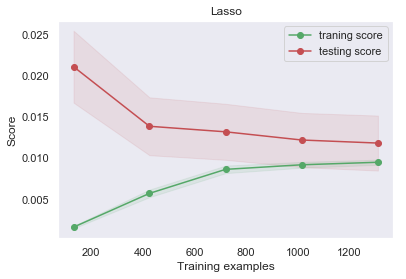

```python
from sklearn.model_selection import learning_curve
import matplotlib.pyplot as plt
%matplotlib inline

def plot_learning_curve(estimator, title, X, y, cv=10,
                        train_sizes=np.linspace(.1, 1.0, 5)):  # 定义 plot_learning_curve 函数绘制学习曲线
    plt.figure()
    plt.title(title)  # 图片标题
    plt.xlabel('Training examples')  # 横坐标
    plt.ylabel('Score')  # 纵坐标
    train_sizes, train_scores, test_scores = learning_curve(estimator, X, y, cv=cv, scoring="neg_mean_squared_error",
                                                            train_sizes=train_sizes)  # 交叉验证法计算训练误差，测试误差
    train_scores_mean = np.mean(-train_scores, axis=1)  # 计算训练误差平均值
    train_scores_std = np.std(-train_scores, axis=1)  # 训练误差方差
    test_scores_mean = np.mean(-test_scores, axis=1)  # 测试误差平均值
    test_scores_std = np.std(-test_scores, axis=1)  # 测试误差方差
    plt.grid()  # 增加网格

    plt.fill_between(train_sizes, train_scores_mean - train_scores_std,
                     train_scores_mean + train_scores_std,
                     alpha=0.1, color='g')  # 颜色填充
    plt.fill_between(train_sizes, test_scores_mean - test_scores_std,
                     test_scores_mean + test_scores_std,
                     alpha=0.1, color='r')  # 颜色填充
    plt.plot(train_sizes, train_scores_mean, 'o-', color='g',
             label='traning score')  # 绘制训练误差曲线
    plt.plot(train_sizes, test_scores_mean, 'o-', color='r',
             label='testing score')  # 绘制测试误差曲线
    plt.legend(loc='best')
    return plt

clf = Lasso(alpha=0.0005)
g = plot_learning_curve(clf, 'Lasso', X, y)  # 调用 plot_learning_curve 绘制学习曲线
```

```python
clf = Lasso(alpha=0.0005)  # 参数设置
clf.fit(X, y)
test = data[l_train:].drop('SalePrice', axis=1).values  # 测试集数据
predict = np.exp(clf.predict(test))  # 预测
resul = pd.DataFrame()
resul['SalePrice'] = predict
resul.to_csv('submission.csv', index=False)  # 将结果写入 submission.csv
```

```python
# 查看 submission.csv
pd.read_csv('submission.csv')
```

|  | SalePrice |
| --- | --- |
| 0 | 122132.918213 |
| 1 | 156557.120874 |
| 2 | 186779.184105 |
| 3 | 200943.802175 |
| 4 | 197816.024918 |
| 5 | 171328.724024 |
| 6 | 180026.435299 |
| 7 | 162426.112254 |
| 8 | 190737.230079 |
| 9 | 117930.562678 |
| 10 | 206741.544280 |
| 11 | 97545.402484 |
| 12 | 93134.287059 |
| 13 | 145042.989979 |
| 14 | 114606.727879 |
| 15 | 373612.804452 |
| 16 | 252706.111549 |
| 17 | 276566.155936 |
| 18 | 276224.420570 |
| 19 | 478583.988647 |
| 20 | 322567.371402 |
| 21 | 209515.048817 |
| 22 | 182760.019105 |
| 23 | 161803.751295 |
| 24 | 186811.958840 |
| 25 | 196706.584374 |
| 26 | 333977.968385 |
| 27 | 236914.644079 |
| 28 | 199886.469415 |
| 29 | 244036.154670 |
| ... | ... |
| 1429 | 84904.785360 |
| 1430 | 140044.684169 |
| 1431 | 45312.789674 |
| 1432 | 69593.582173 |
| 1433 | 56436.480044 |
| 1434 | 323312.477915 |
| 1435 | 280118.053399 |
| 1436 | 211645.229165 |
| 1437 | 150430.976958 |
| 1438 | 207576.146001 |
| 1439 | 156420.081093 |
| 1440 | 212338.748551 |
| 1441 | 187107.053097 |
| 1442 | 328890.153562 |
| 1443 | 339330.001780 |
| 1444 | 84618.366658 |
| 1445 | 193766.108785 |
| 1446 | 109865.808539 |
| 1447 | 130495.513652 |
| 1448 | 154379.881896 |
| 1449 | 81658.779970 |
| 1450 | 82231.603506 |
| 1451 | 146421.523271 |
| 1452 | 79891.096401 |
| 1453 | 79934.560259 |
| 1454 | 89038.176153 |
| 1455 | 80893.950408 |
| 1456 | 165996.896910 |
| 1457 | 120254.313868 |
| 1458 | 228932.622019 |

1459 rows × 1 columns